# PPCA0026 - Tarefa de Casa: Teoria da Decisão Bayesiana na Prática

- Show All Code
- Hide All Code
- View Source

Aplicando os Conceitos da Semana 5

Author

Ítalo Guimarães / Sílvio Júnior

Published

July 11, 2025

**Prazo de Entrega:** 2025-06-29 23:59

## Introdução

Nesta tarefa, você aprofundará seu conhecimento sobre o Framework de Decisão Bayesiana. O objetivo é ir além da introdução vista em aula e aplicar o framework completo para tomar decisões ótimas sob incerteza, tanto com crenças a priori quanto com crenças atualizadas por dados (a posteriori).

**Instruções Gerais:**

- Este arquivo serve como seu template de resposta. Preencha as seções marcadas com seu código R, as saídas geradas, e suas análises textuais.
- **Entrega:** Envie dois arquivos: este `.qmd` completo e o arquivo `.html` auto-contido resultante.

## Problema 1: Decisão Ótima com Priori e Custos Discretos

Neste problema, você atuará como um consultor para uma empresa farmacêutica, usando a teoria da decisão para recomendar uma estratégia para o lançamento de um novo medicamento.

### Cenário

Uma empresa está testando um novo medicamento. A decisão a ser tomada é se deve **“Lançar”** o medicamento com base nos resultados de um ensaio clínico ou **“Não Lançar”**.

- **Hipótese Nula ($H_0$)**: O medicamento não tem efeito (a diferença média de melhora, `d`, é 0).
- **Hipótese Alternativa ($H_1$)**: O medicamento tem um efeito ($d > 0$).
- **Custos dos Erros**:
  - **Erro Tipo I (Falso Positivo):** Lançar um medicamento ineficaz. O custo ($C_I$) é de **$1,000,000**.
  - **Erro Tipo II (Falso Negativo):** Não lançar um medicamento que é eficaz. O custo ($C_{II}$) depende do tamanho do efeito perdido. A empresa estima que $C_{II}(d) = d \times \$10,000,000$.
- **Crença a Priori**: Antes do ensaio clínico final, a diretoria acredita que há **50% de chance de o medicamento não ter efeito** ($P(d=0) = 0.5$). Se ele tiver um efeito, eles acreditam que as probabilidades são: 50% de chance de ser um efeito “pequeno” ($d=0.2$), 30% de ser “médio” ($d=0.5$), e 20% de ser “grande” ($d=1.0$).
- **O Ensaio Clínico**: O ensaio será realizado com `n=50` pacientes por grupo e $\sigma=1$.

### Parte A: A Decisão a Priori

#### 1. Calcule as Probabilidades a Priori

```r
# Calcule as probabilidades a priori para cada estado do mundo:
# d=0, d=0.2, d=0.5, d=1.0

# Probabilidade de não ter efeito
p_nulo <- 0.5

# Probabilidades condicionais para os efeitos, dado que há efeito
p_pequeno <- 0.5
p_medio   <- 0.3
p_grande  <- 0.2

# Probabilidades marginais
p_efeito <- 1 - p_nulo
p_d_0.2  <- p_efeito * p_pequeno   # 0.5 * 0.5 = 0.25
p_d_0.5  <- p_efeito * p_medio     # 0.5 * 0.3 = 0.15
p_d_1.0  <- p_efeito * p_grande    # 0.5 * 0.2 = 0.10

#Vetor de estados e probabilidades
estados_do_mundo <- c(0, 0.2, 0.5, 1.0)
probabilidades_a_priori <- c(p_nulo, p_d_0.2, p_d_0.5, p_d_1.0)

# Armazene-as em um vetor ou data frame.
probabilidades_df <- data.frame(
  Estado = estados_do_mundo,
  Probabilidade = probabilidades_a_priori
)

print(probabilidades_df)
```

```
  Estado Probabilidade
1    0.0          0.50
2    0.2          0.25
3    0.5          0.15
4    1.0          0.10
```

```r
knitr::kable(probabilidades_df, caption = "Probabilidades a Priori para cada estado")
```

Probabilidades a Priori para cada estado

| Estado | Probabilidade |
| --- | --- |
| 0.0 | 0.50 |
| 0.2 | 0.25 |
| 0.5 | 0.15 |
| 1.0 | 0.10 |

**Análise da Tarefa 1.A.1:**

A tabela acima mostra que, de acordo com as crenças da diretoria, há 50% de chance do medicamento não ter efeito (d = 0). Caso haja efeito (probabilidade 0,5), ele pode ser pequeno (d = 0,2; 25%), médio (d = 0,5; 15%) ou grande (d = 1,0; 10%). Essas probabilidades foram obtidas multiplicando a chance de existir efeito (0,5) pelas probabilidades condicionais de cada tamanho de efeito. Assim, temos uma distribuição discreta para os possíveis estados do mundo, que será usada para calcular os riscos esperados nas próximas etapas.

#### 2. Simule o Risco Esperado a Priori

```r
# Você precisará de uma função para calcular o poder, como a da tarefa anterior.
# Se necessário, defina-a aqui.

set.seed(2024)

calcular_poder <- function(n, d, sigma, alpha, num_sim = 10000) {

  # Simula estatísticas sob H1 (d > 0)
  estatisticas <- rnorm(num_sim, mean = d, sd = sigma / sqrt(n))

  #ajustando as estatísticas para ficarem normalizadas (normal padrao)
  estatisticas2 <- (estatisticas) / (sigma / sqrt(n))

  # Calcula o valor crítico para teste unilateral (superior)
  z_critico <- qnorm(1 - alpha)
  # Poder: proporção de vezes que rejeita H0
  poder <- mean(abs(estatisticas2) > z_critico)
  return(poder)
}

# Defina os parâmetros da simulação

# Parâmetros do estudo
n <- 50
sigma <- 1
num_sim <- 10000


C_I <- 1e6

#C_I <- 200000

# Estados e probabilidades
estados_do_mundo <- c(0, 0.2, 0.5, 1.0)
probabilidades_a_priori <- c(0.5, 0.25, 0.15, 0.10)

# Função de custo tipo II
C_II <- function(d) d * 1e7

# Valores de alpha para simular
alpha_seq <- seq(0.001, 1, length.out = 100)

# Escreva seu loop ou use `sapply` para calcular o Risco(α) para uma gama de α.

# Simulação do risco esperado para cada alpha
risco_esperado <- sapply(alpha_seq, function(alpha) {
  # Erro tipo I (lançar quando d=0)
  risco_tipo_I <- probabilidades_a_priori[1] * alpha * C_I

  # Erro tipo II (não lançar quando d>0)
  risco_tipo_II <- sum(
    sapply(2:4, function(i) {
      d <- estados_do_mundo[i]
      p <- probabilidades_a_priori[i]
      poder <- calcular_poder(n, d, sigma, alpha, num_sim)
      p * (1 - poder) * C_II(d)
    })
  )

  risco_tipo_I + risco_tipo_II
})

# Data frame para visualização
df_risco <- data.frame(alpha = alpha_seq, risco = risco_esperado)

# Visualize os primeiros valores
head(df_risco)
```

```
       alpha    risco
1 0.00100000 724700.0
2 0.01109091 487220.5
3 0.02118182 430390.9
4 0.03127273 390911.4
5 0.04136364 354231.8
6 0.05145455 341927.3
```

#### 3. Encontre a Regra de Decisão Ótima

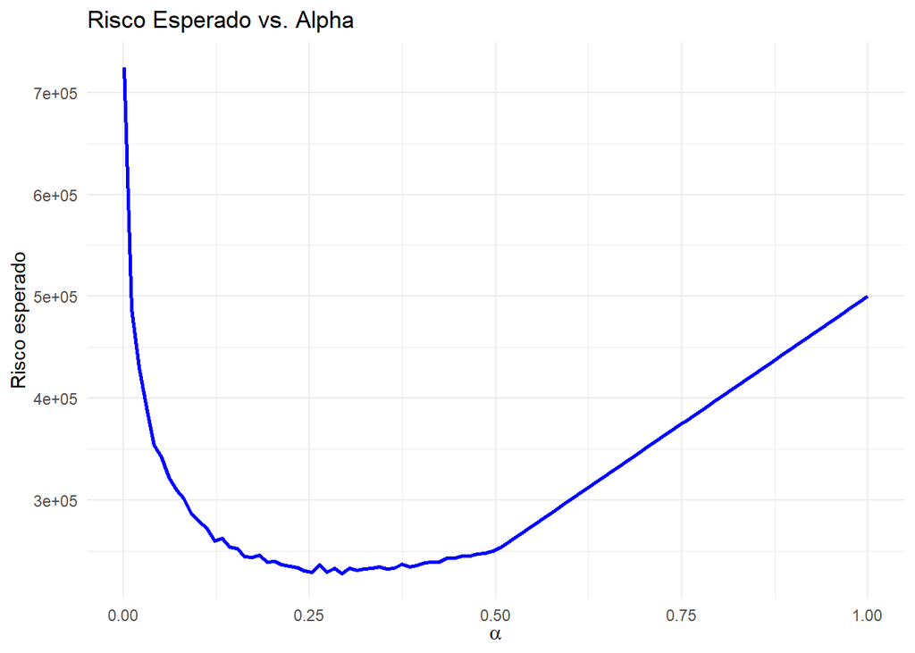

```r
# Plote o Risco Esperado vs. α
# ... seu código ggplot2 aqui ...

library(ggplot2)

ggplot(df_risco, aes(x = alpha, y = risco)) +
  geom_line(color = "blue", size = 1) +
  labs(
    title = "Risco Esperado vs. Alpha",
    x = expression(alpha),
    y = "Risco esperado"
  ) +
  theme_minimal()
```

```r
# Encontre e reporte o α_ótimo e o risco mínimo correspondente

# Encontrar o alpha ótimo e o risco mínimo
idx_min <- which.min(df_risco$risco)
alpha_otimo <- df_risco$alpha[idx_min]
risco_minimo <- df_risco$risco[idx_min]
```

```
Alpha ótimo: 0.2936
```

```
Risco mínimo: 227568.2
```

**Análise da Tarefa 1.A.3:**

Podemos perceber que o risco mínimo é atingido quando o alpha é `0,29`. Cabe destacar que o ponto ótimo de alpha é aquele que minimiza o risco total esperado, equilibrando ambos os tipos de erro.

#### 4. Tome a Decisão a Priori

```r
# Calcule o risco da estratégia "Não Lançar"
options(scipen = 999)

termo_tipo_II <- sum(
  mapply(function(d, p) {
    p * C_II(d)
  }, estados_do_mundo[-1], probabilidades_a_priori[-1])
)


#calule o risco da estratégia "lancar"

termo_tipo_I <- probabilidades_a_priori[1] * C_I
```

```
O risco de não lançar o medicamento dado que ele funciona é 2250000
```

```
O risco de lançar o medicamento dado que ele não funciona é 500000
```

**Análise da Tarefa 1.A.4:**

Como o risco de não lançar é 4,5 vezes maior que o risco de lançar, então a decisão a priori correta seria de `LANÇAR` o medicamento.

### Parte B: A Decisão a Posteriori (Atualização com Dados)

#### Cenário 1: Dados Desanimadores ($\hat{d}_1 = 0.15, SE = 0.2$)

```r
# 1. Calcule a verossimilhança para cada estado do mundo d
dados_crencas <- tibble(
  estado_d = c(0, 0.2, 0.5, 1.0),
  priori = c(0.50, 0.25, 0.15, 0.10)
)

# Dados observados no estudo piloto (Cenário 1)
d_observado <- 0.15
erro_padrao_observado <- 0.2

# A verossimilhança é a probabilidade dos dados (d_obs=0.15)
# para cada possível estado do mundo (d).

dados_atualizados <- dados_crencas %>%
  mutate(
    verossimilhanca = dnorm(x = d_observado,
                            mean = estado_d,
                            sd = erro_padrao_observado)
  )

# 2. Calcule as probabilidades a posteriori

dados_atualizados <- dados_atualizados %>%
  mutate(
    numerador_bayes = verossimilhanca * priori,
    # A Evidência é a soma de todos os numeradores
    evidencia_total = sum(numerador_bayes),
    # A probabilidade a posteriori é o numerador dividido pela evidência
    posteriori = numerador_bayes / evidencia_total
  )

# 3. Calcule o Risco Esperado a Posteriori para "Lançar" e "Não Lançar"
termo_tipo_II_post <- sum(
  mapply(function(d, p) {
    p * C_II(d)
  }, dados_atualizados$estado_d[-1], dados_atualizados$posteriori[-1])
)


termo_tipo_I_post <- dados_atualizados$posteriori[1] * C_I
```

```
O risco de não lançar o medicamento dado que ele funciona no cenário 1 é $ 991958.1
```

```
O risco de lançar o medicamento dado que ele não funciona no cenário 1 é $ 578705.1
```

```
A ação ótima a posteriori é LANÇAR o medicamento no cenário 1.
```

**Análise do Cenário 1:**

Como podemos ver, o risco de não lançar o medicamento dado que ele funciona é $991.958,1, enquanto o risco de lançar dado que ele não funciona é $578.705,1. Portanto, a ação ótima a posteriori é `LANÇAR` o medicamento neste cenário. Cabe destacar que, mesmo nesse cenário ruim, na qual a diferença é tão pequena no tamanho do efeito do remédio, como o custo do erro tipo II é muito alto, a decisão será sempre de lançar.

#### Cenário 2: Dados Promissores ($\hat{d}_2 = 0.60, SE = 0.2$)

```r
# Dados observados no estudo piloto (Cenário 2)
d_observado <- 0.6
erro_padrao_observado <- 0.2

# A verossimilhança é a probabilidade dos dados (d_obs=0.6)
# para cada possível estado do mundo (d).

dados_atualizados <- dados_crencas %>%
  mutate(
    verossimilhanca = dnorm(x = d_observado,
                            mean = estado_d,
                            sd = erro_padrao_observado)
  )

# 2. Calcule as probabilidades a posteriori

dados_atualizados <- dados_atualizados %>%
  mutate(
    numerador_bayes = verossimilhanca * priori,
    # A Evidência é a soma de todos os numeradores
    evidencia_total = sum(numerador_bayes),
    # A probabilidade a posteriori é o numerador dividido pela evidência
    posteriori = numerador_bayes / evidencia_total
  )

# 3. Calcule o Risco Esperado a Posteriori para "Lançar" e "Não Lançar"
termo_tipo_II_post <- sum(
  mapply(function(d, p) {
    p * C_II(d)
  }, dados_atualizados$estado_d[-1], dados_atualizados$posteriori[-1])
)


termo_tipo_I_post <- dados_atualizados$posteriori[1] * C_I
```

```
O risco de não lançar o medicamento dado que ele funciona no cenário 2 é $ 4667526
```

```
O risco de lançar o medicamento dado que ele não funciona no cenário 2 é $ 29976.29
```

```
A ação ótima a posteriori é LANÇAR o medicamento no cenário 2.
```

**Análise do Cenário 2:**

Por fim, no cenário 2, o risco de não lançar o medicamento dado que ele funciona é $4.667.526, enquanto o risco de lançar dado que ele não funciona é $29.976,29. Portanto, a ação ótima a posteriori continua sendo `LANÇAR` o medicamento neste cenário. Isso já era esperado, pois o tamanho do efeito é maior que o do cenário 1, e o custo do erro tipo II é muito alto.

Cabe destacar que, se a diferença entre os custos fossem menores, talvez a decisão entre os cenários fossem diferentes. Por exemplo, se o custo do erro tipo II fosse menor, poderíamos ter uma situação onde a decisão ótima fosse lançar o medicamento no cenário 1, onde a diferença entre o tamanho do efeito era menor, e não lançar no cenário 2, onde o tamanho do efeito é maior. Isso mostra como a modelagem de crenças a priori e os custos dos erros influenciam as decisões.